# PCA Test

Doynikov A.N.

2024-03-26

Дан файл с доходностями облигаций США rt=rt(1),…,rt(N)

Данные взяты с государственного сайта США https://www.treasury.gov/resource-center/data-chart-center/interest-rates/Pages/TextView.aspx?data=yieldYear&year=2019

В США принята такая запись кадендарных дат 3/30/23- 30 марта 2023 года

Прочитать данные

```r
rates <- read.csv("./rates.csv",header = TRUE,row.names = 1 )
head(rates)
```

```
##           X1M  X2M  X3M  X6M  X1Y  X2Y  X3Y  X5Y  X7Y X10Y X20Y X30Y
## 01/03/22 0.05 0.06 0.08 0.22 0.40 0.78 1.04 1.37 1.55 1.63 2.05 2.01
## 01/04/22 0.06 0.05 0.08 0.22 0.38 0.77 1.02 1.37 1.57 1.66 2.10 2.07
## 01/05/22 0.05 0.06 0.09 0.22 0.41 0.83 1.10 1.43 1.62 1.71 2.12 2.09
## 01/06/22 0.04 0.05 0.10 0.23 0.45 0.88 1.15 1.47 1.66 1.73 2.12 2.09
## 01/07/22 0.05 0.05 0.10 0.24 0.43 0.87 1.17 1.50 1.69 1.76 2.15 2.11
## 01/10/22 0.05 0.06 0.13 0.28 0.46 0.92 1.21 1.53 1.71 1.78 2.15 2.11
```

Название колонок это срок до окончания 1 месяц, 2 месяца, …,1 год, …, 30 лет, будем называть это maturity. Вектор maturities соответственно будет

```r
maturities <- c(1/12,2/12,3/12,0.5,1,2,3,5,7,10,20,30)
round(maturities,3)
```

```
##  [1]  0.083  0.167  0.250  0.500  1.000  2.000  3.000  5.000  7.000 10.000
## [11] 20.000 30.000
```

- Провести к доходностям метод главных компонент

(Skipped Code)

- Найти вектор накопленной меры информативности

(Skipped Code)

```
##     PC1     PC2     PC3     PC4     PC5     PC6     PC7     PC8     PC9    PC10
## 0.95123 0.98873 0.99806 0.99909 0.99955 0.99971 0.99984 0.99991 0.99994 0.99997
##    PC11    PC12
## 0.99999 1.00000
```

Запомните накопленную меру информативности в переменную **Cumulative** Убедитесь, что первые 3 фактора будут объяснять более 99% дисперсии доходностей

- Получите 3 главных фактора **shift**,**twist**,**butterfly** $F_1,F_2,F_3$

(Skipped Code)

(Skipped Code)

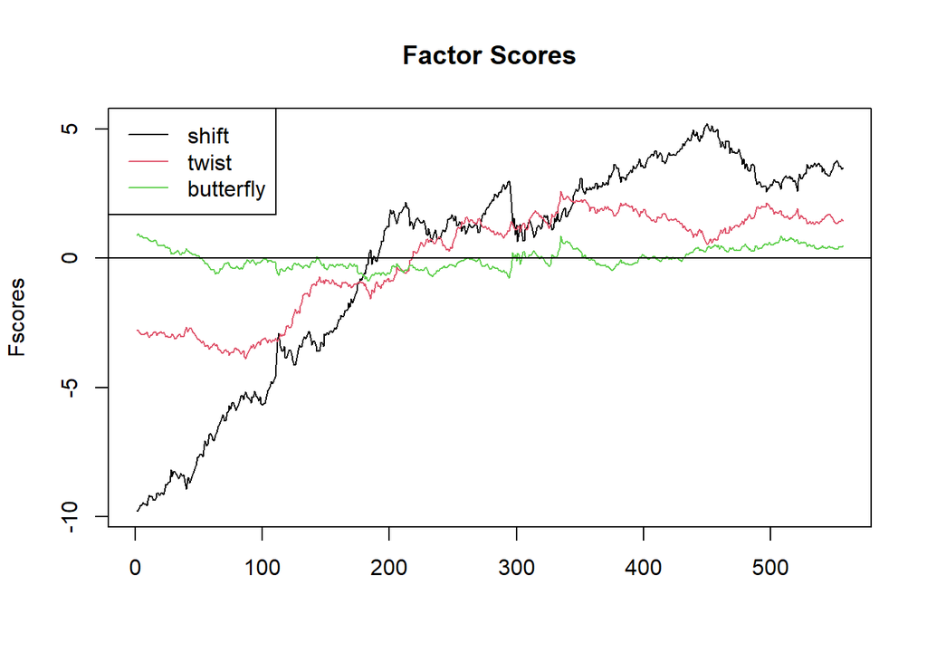

```r
matplot(Fscores,type = 'l',lty = 1, col = 1:number,main = 'Factor Scores')
legend('topleft',c('shift','twist','butterfly'),col = 1:number,lty = 1)
abline(h=0)
```

- Получите матрицу размера [12,3] главных нагрузок **shift,twist,butterfly**. Поместите ее в переменную **Loadings**

(Skipped Code)

```
##           [,1]        [,2]         [,3]
## X1M  0.2824643  0.40132109  0.303548256
## X2M  0.2856057  0.37908737  0.152870511
## X3M  0.2864267  0.36946573  0.081542821
## X6M  0.2889998  0.30541956 -0.137689141
## X1Y  0.2916073  0.18475126 -0.323541342
## X2Y  0.2926234 -0.03831936 -0.430630553
## X3Y  0.2906401 -0.18388417 -0.420540957
## X5Y  0.2896909 -0.28695346 -0.191806015
## X7Y  0.2894792 -0.30647232  0.006520278
## X10Y 0.2892831 -0.29527328  0.199513676
## X20Y 0.2884116 -0.28435631  0.320890560
## X30Y 0.2887251 -0.22742238  0.460756597
```

- Cоздайте перенную **var** и сохраните в ней номер Вашего варианта.

```r
  var <- 0
```

*Следующие задания зависят от номера варианта*

- Восстановите для заданного в варианте даты доходности по 3 факторам и сравните с оригинальными. Востановленные доходности для заданной даты поместите в вектор с именем **restored_data_rates**.

(Skipped Code)

(Skipped Code)

```
##      X1M      X2M      X3M      X6M      X1Y      X2Y      X3Y      X5Y
## 5.355018 5.407059 5.456725 5.441159 5.180844 4.623777 4.286979 4.096866
##      X7Y     X10Y     X20Y     X30Y
## 4.153703 4.208701 4.599996 4.583541
```

**Небольшое изменение в maturities за несколько дней между заданными датами считаем незначительным и не учитываем**

```r
library(FinAna)
portfolio <- c(150,150,150,15,200,15,20,20,10,10,100,100)
```

```r
par <- 1000
m <- 2
coupon <- 0.09
```

(Skipped Code)

```
## [1] 992.8944
```

```r
(portfolio_change <-price2-price1)
```

```
## [1] -194.9914
```

- Предположим что тот же портфель куплен в последний день наблюдений т.е. 03/25/24 Провести анализ What-If для последнего дня на предмет. Каков прогноз изменения стоимости портфеля если один из факторов Twist или Batterfly (см. свой вариант) изменится на следующий день на заданное число процентов. Остальные факторы не изменятся. Нагрузки также не меняются. Какое изменение портфеля при этом?

(Skipped Code)

```
##            PC1      PC2      PC3
## FLast 3.515219 1.464785 0.480577
## FNext 3.515219 1.757742 0.480577
```

```
##            X1M      X2M      X3M      X6M      X1Y      X2Y      X3Y      X5Y
## FLast 5.355018 5.407059 5.456725 5.441159 5.180844 4.623777 4.286979 4.096866
## FNext 5.472588 5.518115 5.564963 5.530634 5.234968 4.612551 4.233109 4.012801
##            X7Y     X10Y     X20Y     X30Y
## FLast 4.153703 4.208701 4.599996 4.583541
## FNext 4.063920 4.122199 4.516692 4.516916
```

```r
(forecast_change <-price2-price1)
```

```
## [1] -1604.594
```

Изменение цены портфеля между ценой прогнозной и ценой последнего дня поместите в переменную **forecast_change**

- Создайте переменную **result** типа list() в которую занесите подготовленные переменные

```r
result = list(
    var = var,
    Cumulative = Cumulative,
    Fscores = Fscores,
    Loadings = Loadings,
    restored_data_rates= restored_data_rates,
    portfolio_change = portfolio_change,
    forecast_change= forecast_change
)
```

- Сохраните переменную **result** в формате RDS в файл

```r
 saveRDS(result,'result.rds')
```

Запустите программу для проверки по ссылке

https://shiny.ilykei.com/ANDoynikov/Tests/test6/

Смотрите результат

Число попыток 10. В варианте с номером 0 не ограничено. Вариант 0 для отладки Вашего кода.

## Варианты

### Вариант 0

$t_1 =$ 03/22/24

$t_2 =$ 03/25/24

Twist 20%

### Вариант 1

$t_1 =$ 02/23/22

$t_2 =$ 03/01/22

Twist 20%

### Вариант 2

$t_1 =$ 02/23/22

$t_2 =$ 03/01/22

Butterfly 20%

### Вариант 3

$t_1 =$ 02/24/22

$t_2 =$ 03/01/22

Twist -20%

### Вариант 4

$t_1 =$ 02/24/22

$t_2 =$ 02/01/22

Butterfly -20%

### Вариант 5

$t_1 =$ 06/28/23

$t_2 =$ 06/30/23

Shift 10%

### Вариант 6

$t_1 =$ 06/28/23

$t_2 =$ 06/30/23

Twist -10%

### Вариант 7

$t_1 =$ 06/28/23

$t_2 =$ 06/30/23

Butterfly 10%

### Вариант 8

$t_1 =$ 05/26/23

$t_2 =$ 05/30/23

Shift -10%

### Вариант 9

$t_1 =$ 05/26/23

$t_2 =$ 05/30/23

Twist 20%

### Вариант 10

$t_1 =$ 05/26/23

$t_2 =$ 05/30/23

Butterfly 20%

### Вариант 11

$t_1 =$ 10/12/22

$t_2 =$ 10/13/22

Shift 15%

### Вариант 12

$t_1 =$ 10/12/22

$t_2 =$ 10/13/22

Twist 15%

### Вариант 13

$t_1 =$ 10/12/22

$t_2 =$ 10/13/22

Butterfly 15%

### Вариант 14

$t_1 =$ 11/22/22

$t_2 =$ 11/23/22

Shift 10%

### Вариант 15

$t_1 =$ 11/22/22

$t_2 =$ 11/23/22

Twist -10%

### Вариант 16

$t_1 =$ 11/22/22

$t_2 =$ 11/23/22

Butterfly -10%

### Вариант 17

$t_1 =$ 02/23/22

$t_2 =$ 03/01/22

Twist 20%

### Вариант 18

$t_1 =$ 02/23/22

$t_2 =$ 03/01/22

Butterfly 20%

### Вариант 19

$t_1 =$ 02/24/22

$t_2 =$ 03/01/22

Twist -20%

### Вариант 20

$t_1 =$ 02/24/22

$t_2 =$ 02/01/22

Butterfly -20%

### Вариант 21

$t_1 =$ 06/28/23

$t_2 =$ 06/30/23

Shift 10%

### Вариант 22

$t_1 =$ 06/28/23

$t_2 =$ 06/30/23

Twist -10%

### Вариант 23

$t_1 =$ 06/28/23

$t_2 =$ 06/30/23

Butterfly 10%

### Вариант 24

$t_1 =$ 05/26/23

$t_2 =$ 05/30/23

Shift -10%

### Вариант 25

$t_1 =$ 05/26/23

$t_2 =$ 05/30/23

Twist 20%

### Вариант 26

$t_1 =$ 05/26/23

$t_2 =$ 05/30/23

Butterfly 20%

### Вариант 27

$t_1 =$ 10/12/22

$t_2 =$ 10/13/22

Shift 15%

### Вариант 28

$t_1 =$ 10/12/22

$t_2 =$ 10/13/22

Twist 15%

### Вариант 29

$t_1 =$ 10/12/22

$t_2 =$ 10/13/22

Butterfly 15%

### Вариант 30

$t_1 =$ 11/22/22

$t_2 =$ 11/23/22

Shift 10%

### Вариант 31

$t_1 =$ 11/22/22

$t_2 =$ 11/23/22

Twist -10%

### Вариант 32

$t_1 =$ 11/22/22

$t_2 =$ 11/23/22

Butterfly -10%